# Different Techniches to Analyze Credit Balance

Yoni

# Intro

How good can we predict Credit balance?

What is the best way to check it?

In order to check which method and models better, we will use the Credit data from ILSR package.

About this data:

*[RDocumentation](https://www.rdocumentation.org/packages/ISLR/versions/1.2/topics/Credit)

## set Data

First, let’s set the Environment

### Main Libraries:

# model’s packages- glmnet,randomForest, tensorflow, keras

# visual packages- viridis,hrbrthemes, knitr

Now we will see the data’s structure

6 top rows of our table:

```r
head(Credit[,-1],6) %>%
  kbl() %>%
  kable_material(c("striped", "hover"))
```

| Income | Limit | Rating | Cards | Age | Education | Gender | Student | Married | Ethnicity | Balance |
| --- | --- | --- | --- | --- | --- | --- | --- | --- | --- | --- |
| 14.891 | 3606 | 283 | 2 | 34 | 11 | Male | No | Yes | Caucasian | 333 |
| 106.025 | 6645 | 483 | 3 | 82 | 15 | Female | Yes | Yes | Asian | 903 |
| 104.593 | 7075 | 514 | 4 | 71 | 11 | Male | No | No | Asian | 580 |
| 148.924 | 9504 | 681 | 3 | 36 | 11 | Female | No | No | Asian | 964 |
| 55.882 | 4897 | 357 | 2 | 68 | 16 | Male | No | Yes | Caucasian | 331 |
| 80.180 | 8047 | 569 | 4 | 77 | 10 | Male | No | No | Caucasian | 1151 |

Here a histogram of he credit balance:

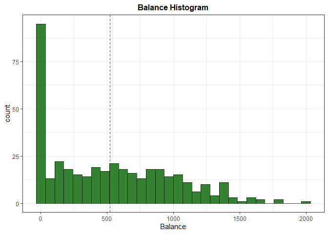

```r
Credit %>%
  ggplot(aes(x=Balance))+
  geom_histogram(color= alpha("black", 0.7),fill= alpha("darkgreen", 0.8) )+
  geom_vline(xintercept= mean(Balance), color= "red",lty= "dashed")+
  theme_bw()+labs(title = "Balance Histogram")+ theme(plot.title = element_text(size=12,hjust = 0.5,face = "bold"))
```

As we can see, $Balance$ is not normal, and has a right tail.

Trying to predict the Balance, one cal ask about race and/or gender bias. Does this factor alone predict the result? and age?

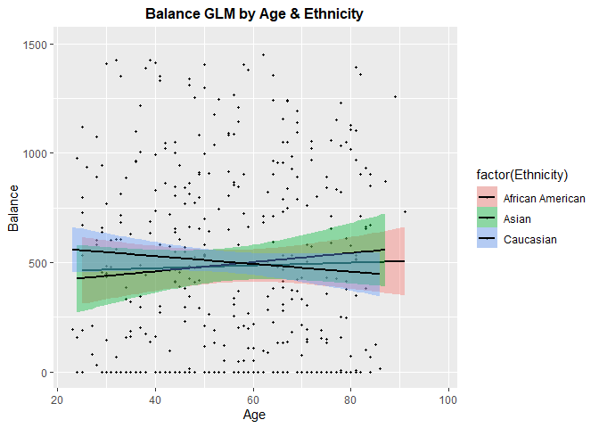

```r
Credit %>%
  ggplot(aes(y=Balance, x=Age,fill= factor(Ethnicity) ))+
  geom_point(size= 0.7)+
  geom_smooth(method = "glm", level= 0.9, color= "black")+ylim(min(Balance), max(1500))+
  labs(title = "Balance GLM by Age & Ethnicity")+ theme(plot.title = element_text(size=12,hjust = 0.5,face = "bold"))
```

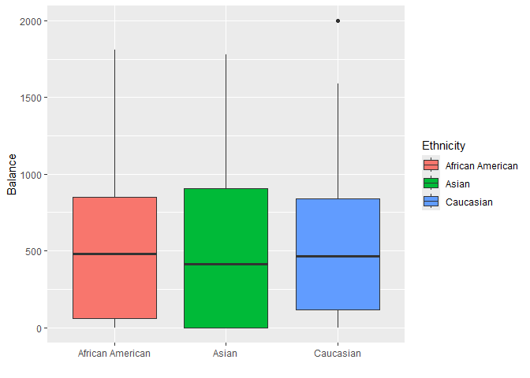

```r
Credit %>%
  ggplot(aes(y=Balance, x=Ethnicity,fill= Ethnicity))+
  geom_boxplot(size= 0.7)+labs(x = "")
```

Prediction of Balance by race & gender

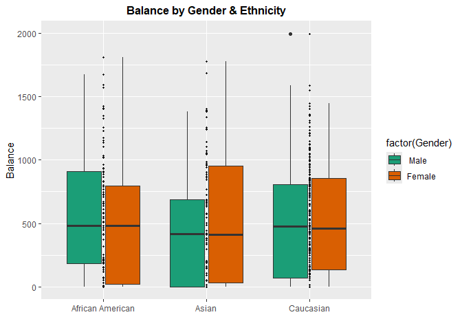

```r
Credit %>%
  ggplot(aes(y=Balance,x= factor(Ethnicity),fill=factor(Gender) ))+
  geom_point(size= 0.7)+
  geom_boxplot(size= 0.7)+scale_fill_brewer(palette="Dark2")+
  labs(x= "", title = "Balance by Gender & Ethnicity")+theme(plot.title = element_text(size=12,hjust = 0.5,face = "bold"))
```

Again, there is no clear effect.

One can ask, can all of the weak predictors create a good one together?

# Models

## Setting the Data

So let’s start!

We will ad some variables.

1. High_deg= $T$ if got more than 12 years of education
2. Age_2= $Age^2$ in order to allaw parabolic age effect
3. Bride= interaction of gender ans marriage

Also, we will set seed and sample train & test.

```r
Credit<- Credit%>%
  mutate(High_deg= Education>=13,
  Age_2= Age^2,
  Bride= (Gender== 'Female')&(Married== 'Yes'))
```

```r
credit_split<- initial_split(Credit, prop = 0.8)
credit_train_split<- training(credit_split)
credit_test_split<-  testing(credit_split)

dolche_de_leche<- function(df) {
  recipe(data=  df, Balance~.) %>%
  update_role(Balance, new_role = "outcome") %>%
  step_novel    (all_nominal(), -all_outcomes(),  new_level = "the_rest")%>%
  step_unknown  (all_nominal(), -all_outcomes(),  new_level= "step_unknown" )%>%
  step_other    (all_nominal(), -all_outcomes(), other = 'step_other', threshold = 10)%>%
  step_nzv      (all_numeric(), -all_outcomes(),freq_cut = 99/1) %>%
  step_normalize(all_numeric(), -all_outcomes())
  }

dolche_credit_train<-credit_train_split%>% dolche_de_leche()%>% prep(credit_train_split)%>% bake(credit_train_split)
dolche_credit_test<- credit_train_split%>% dolche_de_leche()%>% prep(credit_train_split)%>% bake(credit_test_split)
```

Finally, we can predict with our models

## Modeling Balance of 0

Here I create logistic prediction of Balance=0 in order to use in as another variable that we might consider using.

```r
log_data<- dolche_credit_train %>%
  mutate(Balance =  (Balance==0) %>% as.factor())

log_fit <-
  logistic_reg(mode = "classification") %>%
  set_engine(engine = "glm") %>%
  fit(Balance ~ ., data =log_data)

log_pred<- predict(log_fit, new_data = dolche_credit_test)

dolche_credit_train<- cbind(dolche_credit_train,log_data$Balance)
dolche_credit_test<- cbind(dolche_credit_test,log_pred )
```

## Linear

### Classic LM

Assumption: knowing X matrix, Y distributed normal:

$(Y|X) \sim N(BX,\sigma^2)$

```r
lm_par <- linear_reg() %>% set_mode('regression') %>%
  set_engine("lm")
lm_fit <- lm_par %>% fit(Balance ~ . , dolche_credit_train)
lm_pred<- predict(lm_fit, new_data = dolche_credit_test)
# abs(Credit$Balance[testid] - lmpred)

delta_lm<- lm_pred-dolche_credit_test$Balance
delta_lm %>% abs() %>% unlist() %>% mean(na.rm= T)
```

```
## [1] 76.33295
```

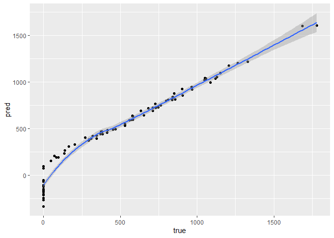

```r
cbind(lm_pred,dolche_credit_test$Balance) %>%
  rename(pred= 1, true= 2) %>%
  ggplot(aes(y=pred, x= true))+
  geom_point()+geom_smooth()
```

Now, what is our best predictors, if we filter our variables and prevent over fitting?

### step wise method

Adding each time variable according to AIC method.

```r
lmfit <- lm(Balance ~ ., data = credit_train_split)

null_model <- lm(Balance ~1, data =  credit_train_split) #null model for starting Stepwise
step_fit <- stepAIC (null_model,k= 2, direction = "forward",scope = list(lower= formula(null_model),upper= formula(lmfit) ) )
```

```
## Start:  AIC=3934.86
## Balance ~ 1
##
##             Df Sum of Sq      RSS    AIC
## + Rating     1  50953599 18661789 3515.6
## + Limit      1  50798907 18816481 3518.2
## + Income     1  14214109 55401279 3863.8
## + Student    1   5503434 64111954 3910.5
## + Cards      1    435141 69180247 3934.8
## <none>                   69615388 3934.9
## + Bride      1    308476 69306912 3935.4
## + ID         1     22714 69592674 3936.8
## + Age        1     13720 69601667 3936.8
## + High_deg   1     11055 69604333 3936.8
## + Age_2      1     10287 69605101 3936.8
## + Education  1      7673 69607715 3936.8
## + Gender     1      3386 69612002 3936.8
## + Married    1      1793 69613595 3936.8
## + Ethnicity  2     88356 69527032 3938.4
##
## Step:  AIC=3515.57
## Balance ~ Rating
##
##             Df Sum of Sq      RSS    AIC
## + Income     1   9683475  8978314 3283.4
## + Student    1   5627357 13034432 3402.7
## + Age_2      1    891053 17770736 3501.9
## + Age        1    754561 17907228 3504.4
## + Cards      1    178222 18483567 3514.5
## <none>                   18661789 3515.6
## + Married    1     70818 18590971 3516.4
## + ID         1     59212 18602578 3516.6
## + Education  1     35255 18626534 3517.0
## + Limit      1     18646 18643143 3517.3
## + Bride      1     12530 18649259 3517.4
## + High_deg   1      2637 18659152 3517.5
## + Gender     1      1020 18660769 3517.6
## + Ethnicity  2     72134 18589655 3518.3
##
## Step:  AIC=3283.44
```

[output cut: 63 more lines]

```
## + Ethnicity  2     17644 3068372 2949.9
##
## Step:  AIC=2944.6
## Balance ~ Rating + Income + Student + Limit + Cards + Age_2
##
##             Df Sum of Sq     RSS    AIC
## <none>                   3037165 2944.6
## + ID         1   11301.0 3025864 2945.4
## + Education  1   11265.2 3025900 2945.4
## + Gender     1    3492.6 3033672 2946.2
## + Married    1    3340.3 3033824 2946.2
## + High_deg   1     914.6 3036250 2946.5
## + Bride      1     110.9 3037054 2946.6
## + Age        1      14.7 3037150 2946.6
## + Ethnicity  2   13578.7 3023586 2947.2
```

```r
step_pred <- predict(step_fit , credit_test_split)
err_step<- abs(credit_test_split$Balance - step_pred)
mean(abs(err_step))
```

```
## [1] 76.23023
```

```r
tab_model(lmfit,step_fit, show.ci= F,show.se = T,show.loglik= T)
```

|  | Balance |  |  | Balance |  |  |
| --- | --- | --- | --- | --- | --- | --- |
| Predictors | Estimates | std. Error | p | Estimates | std. Error | p |
| (Intercept) | -455.43 | 75.38 | **<0.001** | -521.67 | 23.54 | **<0.001** |
| ID | 0.04 | 0.05 | 0.380 |  |  |  |
| Income | -7.86 | 0.26 | **<0.001** | -7.83 | 0.26 | **<0.001** |
| Limit | 0.19 | 0.04 | **<0.001** | 0.19 | 0.04 | **<0.001** |
| Rating | 1.18 | 0.56 | **0.037** | 1.21 | 0.55 | **0.028** |
| Cards | 19.24 | 4.83 | **<0.001** | 18.55 | 4.74 | **<0.001** |
| Age | -0.61 | 2.24 | 0.787 |  |  |  |
| Education | -4.76 | 3.28 | 0.148 |  |  |  |
| Gender $$Female$$ | -27.42 | 18.29 | 0.135 |  |  |  |
| Student $$Yes$$ | 436.37 | 18.40 | **<0.001** | 435.78 | 18.14 | **<0.001** |
| Married $$Yes$$ | -23.38 | 16.54 | 0.159 |  |  |  |
| Ethnicity $$Asian$$ | 14.24 | 15.71 | 0.366 |  |  |  |
| Ethnicity $$Caucasian$$ | 9.55 | 13.68 | 0.486 |  |  |  |
| High degTRUE | 20.73 | 21.21 | 0.329 |  |  |  |
| Age 2 | -0.00 | 0.02 | 0.958 | -0.01 | 0.00 | **0.026** |
| BrideTRUE | 34.90 | 23.51 | 0.139 |  |  |  |
| Observations | 320 |  |  | 320 |  |  |
| R<sup>2</sup> / R<sup>2</sup> adjusted | 0.957 / 0.955 |  |  | 0.956 / 0.956 |  |  |
| log-Likelihood | -1915.525 |  |  | -1919.359 |  |  |

### lasso

Assumption

$(Y|X) \sim N(BX,\sigma^2)$ , like LM.

$RSS+ \lambda {\Sigma}_{j=1}^p |\beta_j|$

when $p=length( \beta)$ and $\lambda$ is a hyper parameter.

*[see also](https://cran.r-project.org/web/packages/glmnet/vignettes/glmnet.pdf)

```r
lasso_par <- linear_reg(mixture = 1,penalty = 0.01) %>% set_mode('regression') %>%
  set_engine("glmnet")
lasso_fit <- lm_par %>% fit(Balance ~ . , dolche_credit_train)
lasso_pred<- predict(lasso_fit, new_data = dolche_credit_test)
# abs(Credit$Balance[testid] - lmpred)

delta_lasso<- lasso_pred-dolche_credit_test$Balance
delta_lasso %>% abs() %>% unlist() %>% mean(na.rm= T)
```

```
## [1] 76.33295
```

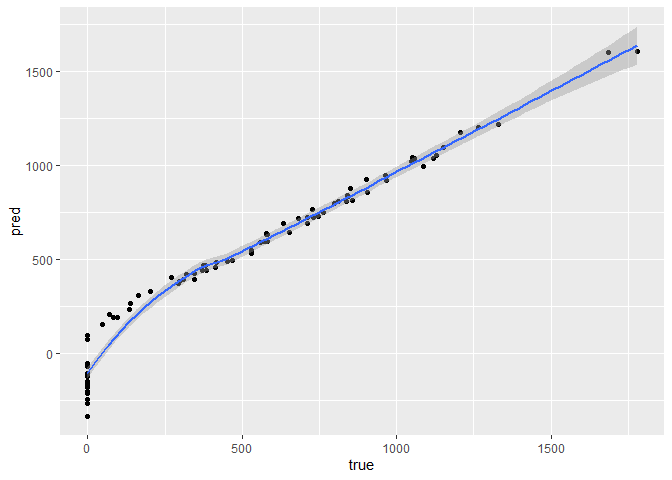

```r
cbind(lasso_pred,dolche_credit_test$Balance) %>%
  rename(pred= 1, true= 2) %>%
  ggplot(aes(y=pred, x= true))+
  geom_point()+geom_smooth()
```

## Trees

The main algorithm in random forest, adaboost, etc is splitting the data each time into two samples, in the most effective way by reevaluating the error function.

Mathematically, the tree assume a model of form

$f(x)= \sum^M_{m=1} c_m*I(x \in R_m) +\epsilon$

while $M$ is the numbers of groups, $R_m$ is the specific group & $c_m$ is the parameter of the model.

For a small tree,this is a very weak learner, but it can be used to create deeper learning. A complicated tree can lead to over-feeting.

### Random Forest

A mean of n-tree

```r
rf_s<- rand_forest(mode = "regression", trees = 1500, min_n = 5)%>%
  set_mode("regression") %>% set_engine("randomForest")

rf_fit<- rf_s %>% fit(Balance ~ . , dolche_credit_train)
rf_pred <- predict(rf_fit, new_data = dolche_credit_test)

delta_rf<- rf_pred-dolche_credit_test$Balance
delta_rf %>% abs() %>% unlist() %>% mean(na.rm= T)

cbind(rf_pred,dolche_credit_test$Balance) %>%
  rename(pred= 1, true= 2) %>%
  ggplot(aes(y=pred, x= true))+
  geom_point()+geom_smooth()
```

[output not shown]

```r
rf_spec <- rand_forest(mode = "regression",
  trees = 800,
  min_n = tune(), mtry = tune() ) %>%
  set_engine("randomForest") %>% set_mode("regression")
rf_spec
```

```
## Random Forest Model Specification (regression)
##
## Main Arguments:
##   mtry = tune()
##   trees = 800
##   min_n = tune()
##
## Computational engine: randomForest
```

```r
rf_grid <- grid_latin_hypercube(
  min_n(),
  finalize(mtry(), dolche_credit_train),
  size = 6)
rf_grid
```

```
## # A tibble: 6 × 2
##   min_n  mtry
##   <int> <int>
## 1    39    13
## 2    20     2
## 3    23     7
## 4     4    10
## 5    12     5
## 6    31    11
```

```r
rf_wf <- workflow() %>%
  add_formula(Balance ~ .) %>%
  add_model(rf_spec)

vb_folds_rf <- vfold_cv(dolche_credit_train, strata = Balance, v= 5)
```

```r
set.seed(234)
rf_res <- tune_grid(
  rf_wf,
  resamples = vb_folds_rf,
  grid = rf_grid,
  control = control_grid(save_pred = TRUE) )
```

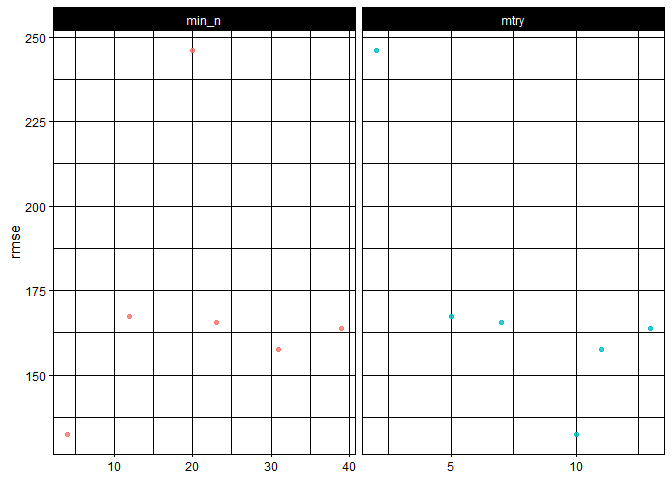

```r
rf_res %>% #???
  collect_metrics() %>%
  filter(.metric == "rmse") %>%
  #select(mean, mtry:tree_depth) %>%
  pivot_longer(mtry:min_n,
               values_to = "value",
               names_to = "parameter") %>%
  ggplot(aes(value, mean, color = parameter)) +
  geom_point(alpha = 0.8, show.legend = FALSE) +
  facet_wrap(~parameter, scales = "free_x") +
  labs(x = NULL, y = "rmse")+theme_linedraw()
```

```r
ggsave("photo_graph/myplot_rf.png")

show_best(rf_res,metric =  "rmse")# %>% select(-.estimator,-n,-.metric)
```

```
## # A tibble: 5 × 8
##    mtry min_n .metric .estimator  mean     n std_err .config
##   <int> <int> <chr>   <chr>      <dbl> <int>   <dbl> <chr>
## 1    10     4 rmse    standard    132.     5    13.7 Preprocessor1_Model4
## 2    11    31 rmse    standard    157.     5    11.7 Preprocessor1_Model6
## 3    13    39 rmse    standard    164.     5    12.5 Preprocessor1_Model1
## 4     7    23 rmse    standard    166.     5    12.6 Preprocessor1_Model3
## 5     5    12 rmse    standard    167.     5    13.7 Preprocessor1_Model5
```

```r
best_tune_rf <- select_best(rf_res, metric = "rmse")
write_csv(best_tune_rf,"data/best_tune_rf.csv") #in any case, I save them to cut reproducing
```

[figure not shown]

```r
best_tune_rf<- read_csv("data/best_tune_rf.csv")
YG_tuned_boost <- rand_forest(mode = "regression", trees = 1500, min_n = best_tune_rf$min_n, mtry =best_tune_rf$mtry,
                           )%>%
  set_mode("regression") %>% set_engine("randomForest")

mod_boost_final<- YG_tuned_boost %>% fit(Balance~ ., data= dolche_credit_train)
rf_pred<-   mod_boost_final %>% predict(new_data= dolche_credit_test)%>% as.data.frame()

delta_rf<- rf_pred-dolche_credit_test$Balance
delta_rf %>% abs() %>% unlist() %>% mean(na.rm= T)
```

```
## [1] 63.84714
```

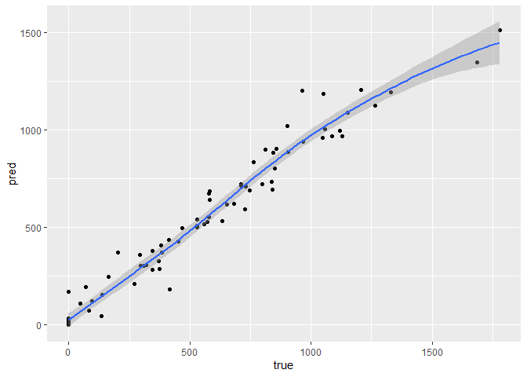

```r
cbind(rf_pred,dolche_credit_test$Balance) %>%
  rename(pred= 1, true= 2) %>%
  ggplot(aes(y=pred, x= true))+
  geom_point()+geom_smooth()
```

___

### XGBoost

Algorithm of gradient boosting trees

```r
xgb_s<-boost_tree(mode = "regression",
                    trees= 1500, min_n= 5) %>%
  set_engine('xgboost') %>% set_mode("regression")

xgb_fit<- xgb_s %>% fit(Balance ~ . , dolche_credit_train)
#rf_pred <- predict(rf_fit, new_data = dolche_credit_test)

pred_xgb<-  predict(xgb_fit, new_data = dolche_credit_test)
err_xgb<- pred_xgb-dolche_credit_test$Balance
err_xgb %>% abs() %>% unlist() %>% mean(na.rm= T)


cbind(pred_xgb,dolche_credit_test$Balance) %>%
  rename(pred= 1, true= 2) %>%
  ggplot(aes(y=pred, x= true))+
  geom_point()+geom_smooth()
```

[output not shown]

```r
xgb_spec <- boost_tree(mode = "regression",
  trees = 800, tree_depth = tune(),sample_size = 0.4,
  min_n = tune(), mtry = tune() ) %>%
  set_engine("xgboost") %>% set_mode("regression")
xgb_spec
```

```
## Boosted Tree Model Specification (regression)
##
## Main Arguments:
##   mtry = tune()
##   trees = 800
##   min_n = tune()
##   tree_depth = tune()
##   sample_size = 0.4
##
## Computational engine: xgboost
```

```r
xgb_grid <- grid_latin_hypercube(
  min_n(),tree_depth(),
  finalize(mtry(), dolche_credit_train),
  size = 6)
xgb_grid
```

```
## # A tibble: 6 × 3
##   min_n tree_depth  mtry
##   <int>      <int> <int>
## 1    38         10    15
## 2    22          3     9
## 3     6         14    11
## 4    28          1     7
## 5    14         12     5
## 6    20          6     3
```

```r
xgb_wf <- workflow() %>%
  add_formula(Balance ~ .) %>%
  add_model(xgb_spec)

vb_folds_xgb <- vfold_cv(dolche_credit_train, strata = Balance, v= 5)
```

```r
set.seed(234)
xgb_res <- tune_grid(
  xgb_wf,
  resamples = vb_folds_xgb,
  grid = xgb_grid,
  control = control_grid(save_pred = TRUE) )
```

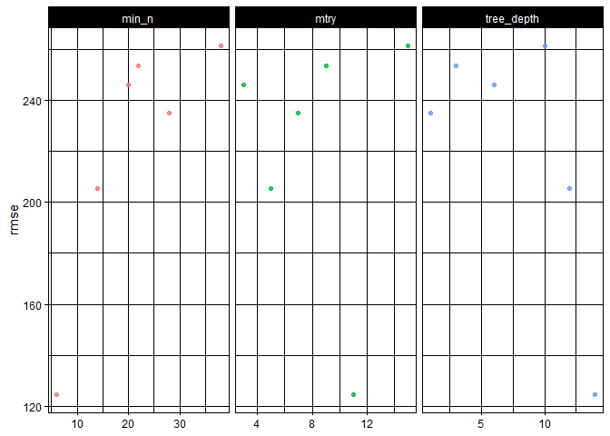

```r
#abc<-
xgb_res %>%
  collect_metrics() %>%
  filter(.metric == "rmse") %>%
  #select(mean, mtry:tree_depth) %>%
  pivot_longer(mtry:tree_depth,
               values_to = "value",
               names_to = "parameter") %>%
  ggplot(aes(value, mean, color = parameter)) +
  geom_point(alpha = 0.8, show.legend = FALSE) +
  facet_wrap(~parameter, scales = "free_x") +
  labs(x = NULL, y = "rmse")+theme_linedraw()
```

```r
ggsave("photo_graph/myplot_xgb.png")

show_best(xgb_res, metric = "rmse")# %>% select(-.estimator,-n,-.metric)
```

```
## # A tibble: 5 × 9
##    mtry min_n tree_depth .metric .estimator  mean     n std_err .config
##   <int> <int>      <int> <chr>   <chr>      <dbl> <int>   <dbl> <chr>
## 1    11     6         14 rmse    standard    124.     5    6.41 Preprocessor1_M…
## 2     5    14         12 rmse    standard    206.     5    9.50 Preprocessor1_M…
## 3     7    28          1 rmse    standard    235.     5   10.9  Preprocessor1_M…
## 4     3    20          6 rmse    standard    246.     5    6.01 Preprocessor1_M…
## 5     9    22          3 rmse    standard    254.     5   10.4  Preprocessor1_M…
```

```r
best_tune_XGB <- select_best(xgb_res, metric = "rmse")
write_csv(best_tune_XGB,"data/best_tune_XGB.csv") #in any case, I save them to cut reproducing
```

[figure not shown]

```r
best_tune_XGB<- read_csv("data/best_tune_XGB.csv")
YG_tuned_boost <- boost_tree(mode = "regression", trees = 1500, min_n = best_tune_XGB$min_n, mtry =best_tune_XGB$mtry,
                           tree_depth= best_tune_XGB$tree_depth )%>%
  set_mode("regression") %>% set_engine("xgboost")

mod_boost_final<- YG_tuned_boost %>% fit(Balance~ ., data= dolche_credit_train)
pred_xgb<-   mod_boost_final %>% predict(new_data= dolche_credit_test)%>% as.data.frame()
err_xgb<- pred_xgb-dolche_credit_test$Balance
err_xgb %>% abs() %>% unlist() %>% mean(na.rm= T)
```

```
## [1] 57.61945
```

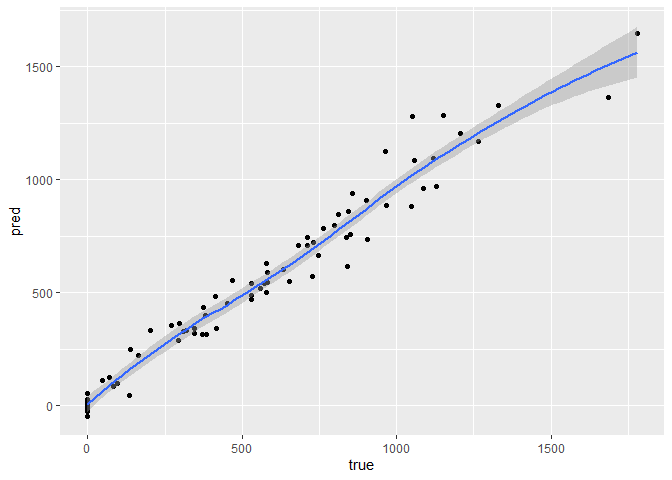

```r
cbind(pred_xgb,dolche_credit_test$Balance) %>%
  rename(pred= 1, true= 2) %>%
  ggplot(aes(y=pred, x= true))+
  geom_point()+geom_smooth()
```

___

```r
#norm_y<- 2*y/(max(y)+min(y))-1
#
#adb_s<-randomForest(formula= Balance ~ ., data = Credit[-testid , ],
                    ntree= 1500, mtry= 14, na.action = na.omit, importance= T )

#pred_abs <- predict(adb_s , Credit[testid , ], s = "lambda.min")
#pred_abs<- head(as.vector(pred_abs),133)
#err_adb<- abs(y[testid] - pred_abs)
#mean(abs(err_adb))
```

## Neural Network

Creating of network of nonlinear function and weights, that evaluate the prediction.

This method is the hardest to present due to the complexitivity of the net.

### set seed

```r
library(keras3)
credit_nn_split<- initial_split(dolche_credit_train, prop = 0.8)
credit_nn_train<- training(credit_nn_split)
credit_nn_test<-  testing(credit_nn_split)

x <- model.matrix(Balance ~ . - 1, data = credit_nn_train)
x_test<- model.matrix(Balance ~ . - 1, data = credit_nn_test)
y <- credit_nn_train$Balance
y_test<- credit_nn_test$Balance

modnn <- keras_model_sequential () %>%
  layer_dense(units = 50, activation = "relu",
              input_shape = ncol(x)) %>%
  layer_dropout(rate = 0.4) %>%
  layer_dense(units = 20, activation = 'relu') %>%
  layer_dense(units = 4, activation = 'sigmoid') %>%
  layer_dropout(rate = 0.2) %>%
  layer_dense(units = 1, activation = 'relu')

modnn %>% compile(loss = "mse",
                  optimizer = optimizer_rmsprop (),
                  metrics = list("mean_absolute_error")
                  )
modnn
```

```
## Model: "sequential"
## ┌───────────────────────────────────┬──────────────────────────┬───────────────
## │ Layer (type)                      │ Output Shape             │       Param #
## ├───────────────────────────────────┼──────────────────────────┼───────────────
## │ dense (Dense)                     │ (None, 50)               │         1,050
## ├───────────────────────────────────┼──────────────────────────┼───────────────
## │ dropout (Dropout)                 │ (None, 50)               │             0
## ├───────────────────────────────────┼──────────────────────────┼───────────────
## │ dense_1 (Dense)                   │ (None, 20)               │         1,020
## ├───────────────────────────────────┼──────────────────────────┼───────────────
## │ dense_2 (Dense)                   │ (None, 4)                │            84
## ├───────────────────────────────────┼──────────────────────────┼───────────────
## │ dropout_1 (Dropout)               │ (None, 4)                │             0
## ├───────────────────────────────────┼──────────────────────────┼───────────────
## │ dense_3 (Dense)                   │ (None, 1)                │             5
## └───────────────────────────────────┴──────────────────────────┴───────────────
##  Total params: 2,159 (8.43 KB)
##  Trainable params: 2,159 (8.43 KB)
##  Non-trainable params: 0 (0.00 B)
```

Using the net:

```r
mod_Credit <- modnn %>% fit(
  x, y, epochs = 1500, batch_size = 32,
  validation_data = list(x_test, y_test))
```

### Keras result

```r
mod_Credit
```

```
##
## Final epoch (plot to see history):
##                    loss: 463,597
##     mean_absolute_error: 501.5
##                val_loss: 401,168
## val_mean_absolute_error: 464.4
```

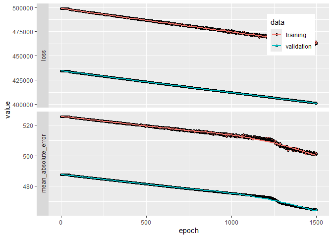

```r
plot(mod_Credit)+theme_gray()+
  theme(plot.caption = element_text(size = 6,hjust= 0),
        legend.position = c(.95, .95),
    legend.justification = c("right", "top"),
    legend.box.just = "right")#,
```

```r
    #legend.margin = margin(6, 6, 6, 6))

dolche_credit_test_nn<- model.matrix(Balance ~ . - 1, data = dolche_credit_test)
y <- dolche_credit_test$Balance

nnpred <- predict(modnn ,dolche_credit_test_nn ) %>% as.data.frame()
```

```
## 3/3 - 0s - 37ms/step
```

```r
err_nn<- abs(y_test - nnpred)
err_nn %>% unlist() %>% mean(na.rm= T)
```

```
## [1] 470.777
```

## Sum all result

We used the same seed to test all methods, so now we can compare the error of each data.

- Each time this scipt were running, we got different result, due to randomness of $testid$ , and of the deep learning models

[figure not shown]

```r
modl_nam<-c('Balance', "Linear", "Lasso", "Random_forrest","xgboost","Neural_network")
order_script<- order(modl_nam[-1])+1

my_pred<- data.frame(cbind(dolche_credit_test$Balance,lm_pred,lasso_pred,rf_pred,pred_xgb,nnpred)) %>%  #pred data frame
   `colnames<-`(modl_nam) %>%
  pivot_longer(cols = 2:6, names_to = "Model")

colnames(my_pred)[3]<- "Predict"

my_err<- my_pred %>% mutate(Delta= Predict- Balance) %>%
  group_by(Model) %>% summarise_at(2, mean)

#caption- var of the models alphabetically

script_base<- map2_chr(my_err$Model, my_err$Predict, function(x,y) {paste0(x, " is ", round(y,3) )})
script<- "SD: "
for (i in script_base) {
  script<- paste(script, ",", i)}
script<- str_remove(script, ", ")

my_pred %>%
  ggplot( aes(x= Model ,y=Balance-Predict, fill= Model)) +
  geom_violin()+
  scale_fill_viridis(discrete = TRUE, alpha=0.6) +
  geom_jitter(color="black", size=0.45) +
  theme_dark() +
  theme(
    legend.position="none",
    plot.title = element_text(size=12,hjust = 0.5,face = "bold"),
    plot.caption = element_text(size = 8,hjust= 0),
    axis.title = element_text(size = 8))+ ylab("Error")+
  labs(title = "Error Violin",caption = script)
```

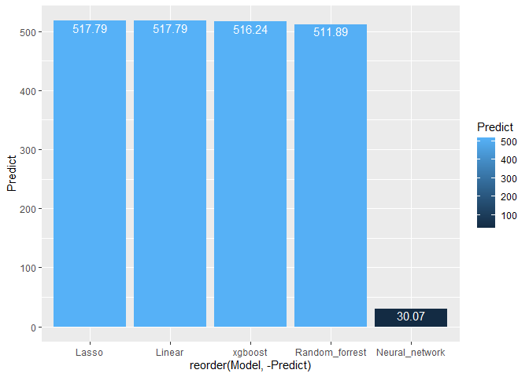

```r
my_err %>%
  ggplot(aes(x= reorder(Model, -Predict), y= Predict, fill= Predict))+
  geom_bar(stat = "identity")+
  geom_text(aes(label = round(Predict,2))  , vjust = +1.2, color= "White")
```

# Discussion